[figure not shown]

# Hito 2: Caracterización y análisis de películas de IMDB

### CC5206 Semestre Primavera 2021

Integrantes: Alan Acevedo, Camila Labarca, Franco Miranda, Julia Paredes

Grupo: 4

Profesores: Andrés Abeliuk, Hernán Sarmiento

Auxiliares: Alison Fernández, Cinthia Sánchez

Fecha de entrega: 10 de noviembre de 2021

## Introducción

En la última década, el mercado de las películas y series ha crecido enormemente gracias a los avances tecnológicos y a plataformas online como Netflix, Hulu, Amazon, Disney+, entre otras. Este tema puede ser bastante interesante de analizar ya que prácticamente todas las personas están familiarizadas con éste ámbito.

El objetivo de este proyecto es aplicar distintas técnicas de minería de datos para realizar un estudio sobre un dataset obtenido de la Internet Movie Database que contiene información sobre películas. Los resultados le podrían ser de bastante utilidad a aspirantes en el mundo del cine, pues les daría una amplia imagen de la industria cinematográfica, y junto con ello entender su comportamiento.

## Mejoras al Hito 1

Las mejoras que se realizarán al Hito 1 son principalmente 2. La primera, es que no solo se tendrá en cuenta la información de las películas, sino que también de los actores, directores y escritores que participaron en ellas, por lo que a la tabla que se había obtenido en el Hito 1 se le agregará esta información. Y la segunda, es que habiendo actualizado el dataset se refinarán las preguntas planteadas al final del Hito 1.

## Dataset

Se trabajó con el dataset de IMDB, el cual está distribuido en 7 tablas en formato TSV, de las cuales se ocuparán cinco.

La tabla title_basics contiene varios atributos de interés sobre títulos:

- titleType: tipo/formato del título (película, cortometraje, documental, etc.)
- primaryTitle: el nombre más popular del título
- startYear: año de lanzamiento original
- runtimeMinutes: duración en minutos
- genres: arreglo de hasta tres géneros asociados al título

La tabla title_ratings contiene dos atributos interesantes:

- averageRating: promedio de todas las valoraciones de los usuarios de IMDB que ha recibido el título
- numVotes: número de valoraciones que el título ha recibido

La tabla title_crew contiene dos atributos de interés:

- directors: id de los directores
- writers: id de los escritores

La tabla title_principals tiene cinco atributos relevantes:

- ordering: número para identificar filas para un mismo titleId
- nconst: identificador único de la persona
- category: la categoría del trabajo de la persona
- job: trabajo específico de la persona
- characters: el nombre del personaje que se actuó, si es aplicable a la persona

La tabla name_basics contiene cinco atributos importantes:

- primaryName: nombre de la persona
- birthYear: fecha de nacimiento
- deathYear: fecha de muerte, si es aplicable
- primaryProfession: top 3 profesiones de la persona
- knownForTitles: títulos por los que la persona es conocida

Se importan las librerías necesarias.

```python
import pandas as pd
import numpy as np
import matplotlib.pyplot as plt
import re
import seaborn as sns
pd.options.mode.chained_assignment = None
```

Se importan los datasets necesarios.

```python
title_basics = pd.read_csv("./datasets/title_basics.tsv", sep='\t', encoding="UTF-8")
title_ratings = pd.read_csv("./datasets/title_ratings.tsv", sep='\t', encoding="UTF-8")
title_crew = pd.read_csv("./datasets/title_crew.tsv", sep='\t', encoding="UTF-8")
name_basics = pd.read_csv("./datasets/name_basics.tsv", sep='\t', encoding="UTF-8")
title_principals = pd.read_csv("./datasets/title_principals.tsv", sep='\t', encoding="UTF-8")
```

Luego, los atributos que correspondan se cambian a categóricos o a númericos

```python
title_basics["runtimeMinutes"] = pd.to_numeric(title_basics["runtimeMinutes"], errors='coerce')
title_basics["genres"] = title_basics["genres"].astype(object)
title_basics["startYear"] = pd.to_numeric(title_basics["startYear"], errors='coerce')
title_basics["titleType"] = title_basics["titleType"].astype(object)
title_basics["isAdult"] = title_basics["isAdult"].astype(object)
title_ratings["averageRating"] = pd.to_numeric(title_ratings["averageRating"], errors='coerce')
title_ratings["numVotes"] = pd.to_numeric(title_ratings["numVotes"], errors='coerce')
```

```python
title_basics.shape[0]
```

```
8246400
```

title_basics tiene 8.246.400 filas.

Para ver cuántos elementos sin valores asignados hay en las tablas se usa la siguiente línea:

```python
title_basics.isna().sum(axis=0)
```

```
tconst                  0
titleType               0
primaryTitle            9
originalTitle           9
isAdult                 0
startYear          971886
endYear                 0
runtimeMinutes    5920699
genres                 10
dtype: int64
```

La columna runtimeMinutes tiene 5.920.699 valores no asignados, lo que corresponde a un gran porcentaje del total de filas. También hay 971.886 valores nulos en startYear. Estos atributos son de interés y podrían ser usados en el estudio, por lo que se hará una limpieza del dataset.

Se realizará un estudio de los datos relacionados a películas, por lo que se filtrará para quitar los títulos de tipo documental o cortometraje, y además solo se considerarán las películas con géneros válidos.

```python
only_movies = title_basics[(title_basics.genres != '\\N') & (title_basics.titleType == "movie")]
```

```python
only_movies.shape[0]
```

```
516492
```

El nuevo dataframe tiene 516.492 filas.

Ahora se puede volver a ver cuantos elementos tienen valores no asignados.

```python
only_movies.isna().sum(axis=0)
```

```
tconst                 0
titleType              0
primaryTitle           0
originalTitle          0
isAdult                0
startYear          70672
endYear                0
runtimeMinutes    170153
genres                 0
dtype: int64
```

```python
only_movies = only_movies.dropna()
```

```python
only_movies.shape[0]
```

```
340916
```

Después de la limpieza de valores nulos, title_basics tiene 340.916 filas. Sigue siendo un número importante de datos que pueden ser estudiados por lo que no es necesario considerar los valores nulos.

Como ya se filtró según la columna titleType, ésta se elimina del dataframe. Además, endYear es siempre \N para las películas, por lo que no entregan información y se eliminan del dataframe. Por último se elimina la columna originalTitle ya que no es de interés (es el nombre de la película en el idioma original).

```python
only_movies.drop('endYear', axis=1, inplace=True)
only_movies.drop('titleType', axis=1, inplace=True)
only_movies.drop('originalTitle', axis=1, inplace=True)
```

Se hace un join de las tablas only_movies y title_ratings para que cada película tenga su valoración promedio y cantidad de valoraciones.

```python
movies = pd.merge(only_movies, title_ratings, on='tconst')
```

### Columnas nuevas

Se crea una nueva tabla que será el join de movies y title_crew por la variable tconst, el identificador de cada película.

```python
movies_2 = pd.merge(movies, title_crew, on='tconst')
movies_2
```

|  | tconst | primaryTitle | isAdult | startYear | runtimeMinutes | genres | averageRating | numVotes | directors | writers |
| --- | --- | --- | --- | --- | --- | --- | --- | --- | --- | --- |
| 0 | tt0000574 | The Story of the Kelly Gang | 0 | 1906.0 | 70.0 | Action,Adventure,Biography | 6.1 | 692 | nm0846879 | nm0846879 |
| 1 | tt0000591 | The Prodigal Son | 0 | 1907.0 | 90.0 | Drama | 5.2 | 16 | nm0141150 | nm0141150 |
| 2 | tt0000679 | The Fairylogue and Radio-Plays | 0 | 1908.0 | 120.0 | Adventure,Fantasy | 5.4 | 65 | nm0877783,nm0091767 | nm0000875,nm0877783 |
| 3 | tt0001184 | Don Juan de Serrallonga | 0 | 1910.0 | 58.0 | Adventure,Drama | 3.4 | 19 | nm0063413,nm0550220 | nm0049370 |
| 4 | tt0001258 | The White Slave Trade | 0 | 1910.0 | 45.0 | Drama | 5.7 | 132 | nm0088881 | \N |
| ... | ... | ... | ... | ... | ... | ... | ... | ... | ... | ... |
| 235204 | tt9916170 | The Rehearsal | 0 | 2019.0 | 51.0 | Drama | 7.2 | 5 | nm5412267 | nm5412267,nm6743460,nm3245789 |
| 235205 | tt9916190 | Safeguard | 0 | 2020.0 | 90.0 | Action,Adventure,Thriller | 3.6 | 222 | nm7308376 | nm7308376 |
| 235206 | tt9916270 | Il talento del calabrone | 0 | 2020.0 | 84.0 | Thriller | 5.8 | 1163 | nm1480867 | nm1480867,nm10538402 |
| 235207 | tt9916362 | Coven | 0 | 2020.0 | 92.0 | Adventure,Drama,History | 6.3 | 3829 | nm1893148 | nm1893148,nm3471432 |
| 235208 | tt9916538 | Kuambil Lagi Hatiku | 0 | 2019.0 | 123.0 | Drama | 8.3 | 6 | nm4457074 | nm4843252,nm4900525,nm2679404 |

235209 rows × 10 columns

Se tiene que trabajar un poco para que aparezcan los nombres de los directores.

```python
movDir = movies_2[['tconst', 'directors']]

# Se crea una lista de los directores
movDir["directors"] = movDir["directors"].str.split(",")

# Se separa cada uno de los directores por su película
md = movDir.explode("directors")

# Se mapea name_basics a la columna de directores
md["directors"] = md["directors"].map(name_basics.set_index("nconst").squeeze()['primaryName']).fillna("")

# Los nombres de los directores se agrupan para cada película
res = md.groupby("tconst").agg(",".join).reset_index()

# Se quitan las comas innecesarias de la nueva columna
res["directors"] = res["directors"].str.strip(",")

res
```

|  | tconst | directors |
| --- | --- | --- |
| 0 | tt0000574 | Charles Tait |
| 1 | tt0000591 | Michel Carré |
| 2 | tt0000679 | Otis Turner,Francis Boggs |
| 3 | tt0001184 | Ricardo de Baños,Alberto Marro |
| 4 | tt0001258 | August Blom |
| ... | ... | ... |
| 235204 | tt9916170 | Tamar Guimaraes |
| 235205 | tt9916190 | Fraser Precious |
| 235206 | tt9916270 | Giacomo Cimini |
| 235207 | tt9916362 | Pablo Agüero |
| 235208 | tt9916538 | Azhar Kinoi Lubis |

235209 rows × 2 columns

Como se obtuvieron los nombres de los directores para cada película, basta unir esta tabla con la original.

```python
movies_3 = pd.merge(movies, res, on='tconst')
movies_3
```

|  | tconst | primaryTitle | isAdult | startYear | runtimeMinutes | genres | averageRating | numVotes | directors |
| --- | --- | --- | --- | --- | --- | --- | --- | --- | --- |
| 0 | tt0000574 | The Story of the Kelly Gang | 0 | 1906.0 | 70.0 | Action,Adventure,Biography | 6.1 | 692 | Charles Tait |
| 1 | tt0000591 | The Prodigal Son | 0 | 1907.0 | 90.0 | Drama | 5.2 | 16 | Michel Carré |
| 2 | tt0000679 | The Fairylogue and Radio-Plays | 0 | 1908.0 | 120.0 | Adventure,Fantasy | 5.4 | 65 | Otis Turner,Francis Boggs |
| 3 | tt0001184 | Don Juan de Serrallonga | 0 | 1910.0 | 58.0 | Adventure,Drama | 3.4 | 19 | Ricardo de Baños,Alberto Marro |
| 4 | tt0001258 | The White Slave Trade | 0 | 1910.0 | 45.0 | Drama | 5.7 | 132 | August Blom |
| ... | ... | ... | ... | ... | ... | ... | ... | ... | ... |
| 235204 | tt9916170 | The Rehearsal | 0 | 2019.0 | 51.0 | Drama | 7.2 | 5 | Tamar Guimaraes |
| 235205 | tt9916190 | Safeguard | 0 | 2020.0 | 90.0 | Action,Adventure,Thriller | 3.6 | 222 | Fraser Precious |
| 235206 | tt9916270 | Il talento del calabrone | 0 | 2020.0 | 84.0 | Thriller | 5.8 | 1163 | Giacomo Cimini |
| 235207 | tt9916362 | Coven | 0 | 2020.0 | 92.0 | Adventure,Drama,History | 6.3 | 3829 | Pablo Agüero |
| 235208 | tt9916538 | Kuambil Lagi Hatiku | 0 | 2019.0 | 123.0 | Drama | 8.3 | 6 | Azhar Kinoi Lubis |

235209 rows × 9 columns

Se hace el mismo proceso anterior para los escritores.

```python
movWri = movies_2[['tconst', 'writers']]

# Se crea una lista de los escritores
movWri["writers"] = movWri["writers"].str.split(",")

# Se separa cada uno de los escritores por su película
mw = movWri.explode("writers")

# Se mapea name_basics a la columna de escritores
mw["writers"] = mw["writers"].map(name_basics.set_index("nconst").squeeze()['primaryName']).fillna("")

# Los nombres de los escritores se agrupan para cada película
res2 = mw.groupby("tconst").agg(",".join).reset_index()

# Se quitan las comas innecesarias de la nueva columna
res2["writers"] = res2["writers"].str.strip(",")

res2
```

|  | tconst | writers |
| --- | --- | --- |
| 0 | tt0000574 | Charles Tait |
| 1 | tt0000591 | Michel Carré |
| 2 | tt0000679 | L. Frank Baum,Otis Turner |
| 3 | tt0001184 | Víctor Balaguer |
| 4 | tt0001258 |  |
| ... | ... | ... |
| 235204 | tt9916170 | Tamar Guimaraes,Lillah Halla,Melissa de Raaf |
| 235205 | tt9916190 | Fraser Precious |
| 235206 | tt9916270 | Giacomo Cimini,Lorenzo Collalti |
| 235207 | tt9916362 | Pablo Agüero,Katell Guillou |
| 235208 | tt9916538 | Arief Ash Siddiq,Rino Sarjono,Salman Aristo |

235209 rows × 2 columns

Se unen las tablas y se elimina una columna innecesaria

```python
movies_4 = pd.merge(movies_3, res2, on='tconst')
movies_4
```

|  | tconst | primaryTitle | isAdult | startYear | runtimeMinutes | genres | averageRating | numVotes | directors | writers |
| --- | --- | --- | --- | --- | --- | --- | --- | --- | --- | --- |
| 0 | tt0000574 | The Story of the Kelly Gang | 0 | 1906.0 | 70.0 | Action,Adventure,Biography | 6.1 | 692 | Charles Tait | Charles Tait |
| 1 | tt0000591 | The Prodigal Son | 0 | 1907.0 | 90.0 | Drama | 5.2 | 16 | Michel Carré | Michel Carré |
| 2 | tt0000679 | The Fairylogue and Radio-Plays | 0 | 1908.0 | 120.0 | Adventure,Fantasy | 5.4 | 65 | Otis Turner,Francis Boggs | L. Frank Baum,Otis Turner |
| 3 | tt0001184 | Don Juan de Serrallonga | 0 | 1910.0 | 58.0 | Adventure,Drama | 3.4 | 19 | Ricardo de Baños,Alberto Marro | Víctor Balaguer |
| 4 | tt0001258 | The White Slave Trade | 0 | 1910.0 | 45.0 | Drama | 5.7 | 132 | August Blom |  |
| ... | ... | ... | ... | ... | ... | ... | ... | ... | ... | ... |
| 235204 | tt9916170 | The Rehearsal | 0 | 2019.0 | 51.0 | Drama | 7.2 | 5 | Tamar Guimaraes | Tamar Guimaraes,Lillah Halla,Melissa de Raaf |
| 235205 | tt9916190 | Safeguard | 0 | 2020.0 | 90.0 | Action,Adventure,Thriller | 3.6 | 222 | Fraser Precious | Fraser Precious |
| 235206 | tt9916270 | Il talento del calabrone | 0 | 2020.0 | 84.0 | Thriller | 5.8 | 1163 | Giacomo Cimini | Giacomo Cimini,Lorenzo Collalti |
| 235207 | tt9916362 | Coven | 0 | 2020.0 | 92.0 | Adventure,Drama,History | 6.3 | 3829 | Pablo Agüero | Pablo Agüero,Katell Guillou |
| 235208 | tt9916538 | Kuambil Lagi Hatiku | 0 | 2019.0 | 123.0 | Drama | 8.3 | 6 | Azhar Kinoi Lubis | Arief Ash Siddiq,Rino Sarjono,Salman Aristo |

235209 rows × 10 columns

Falta vincular los actores con sus películas. Para ello, se debe trabajar de una forma distinta pues el formato de la tabla en donde se encuentran los actores es distinto al resto.

```python
# Se seleccionan las columnas tconst y nconst, los identificadores de las películas y de cada persona, donde
# la persona asociada a cada nconst sea un actor o actriz.
actors_title = title_principals[title_principals['category'].isin(['actor', 'actress'])][['tconst', 'nconst']]

# Se mapea name_basics a la columna de nconst
actors_title['nconst'] = actors_title["nconst"].map(name_basics.set_index("nconst").squeeze()['primaryName']).fillna("")

# Se renombra la columna nconst como actors
actors_title = actors_title.rename(columns={'nconst':'actors'})

# Se consideran solo las películas que estén en la tabla creada anteriormente
actors_title = actors_title[actors_title['tconst'].isin(movies_4['tconst'])]

# Los nombres de los actores se agrupan para cada película
actors_title = actors_title.groupby("tconst").agg(",".join).reset_index()

# Se quitan las comas innecesarias
actors_title["actors"] = actors_title["actors"].str.strip(",")

actors_title
```

|  | tconst | actors |
| --- | --- | --- |
| 0 | tt0000574 | Elizabeth Tait,John Tait,Norman Campbell,Bella... |
| 1 | tt0000591 | Georges Wague,Henri Gouget,Christiane Mandelys... |
| 2 | tt0000679 | L. Frank Baum,Frank Burns,George E. Wilson,Wal... |
| 3 | tt0001184 | Dolores Puchol,Cecilio Rodríguez de la Vega |
| 4 | tt0001258 | Aage Lorentzen,Ellen Diedrich,Victor Fabian,Ju... |
| ... | ... | ... |
| 207478 | tt9916170 | Julia Ianina,Pablo Lafuente,Kelner Macêdo,Germ... |
| 207479 | tt9916190 | Patrick Gallagher,Akie Kotabe,Takayuki Suzuki,... |
| 207480 | tt9916270 | Sergio Castellitto,Lorenzo Richelmy,Anna Fogli... |
| 207481 | tt9916362 | Amaia Aberasturi,Alex Brendemühl,Daniel Fanego... |
| 207482 | tt9916538 | Lala Karmela,Cut Mini Theo,Sahil Shah,Ria Irawan |

207483 rows × 2 columns

Se muestran todos los actores para una película en concreto, por lo tanto, hay que juntar las tablas, eliminar las filas con algún NA (ya sea de director, escritor o actor) y con esto se tiene toda la información.

```python
movies_5 = pd.merge(movies_4, actors_title, on='tconst')
movies_5.dropna()
movies_5
```

|  | tconst | primaryTitle | isAdult | startYear | runtimeMinutes | genres | averageRating | numVotes | directors | writers | actors |
| --- | --- | --- | --- | --- | --- | --- | --- | --- | --- | --- | --- |
| 0 | tt0000574 | The Story of the Kelly Gang | 0 | 1906.0 | 70.0 | Action,Adventure,Biography | 6.1 | 692 | Charles Tait | Charles Tait | Elizabeth Tait,John Tait,Norman Campbell,Bella... |
| 1 | tt0000591 | The Prodigal Son | 0 | 1907.0 | 90.0 | Drama | 5.2 | 16 | Michel Carré | Michel Carré | Georges Wague,Henri Gouget,Christiane Mandelys... |
| 2 | tt0000679 | The Fairylogue and Radio-Plays | 0 | 1908.0 | 120.0 | Adventure,Fantasy | 5.4 | 65 | Otis Turner,Francis Boggs | L. Frank Baum,Otis Turner | L. Frank Baum,Frank Burns,George E. Wilson,Wal... |
| 3 | tt0001184 | Don Juan de Serrallonga | 0 | 1910.0 | 58.0 | Adventure,Drama | 3.4 | 19 | Ricardo de Baños,Alberto Marro | Víctor Balaguer | Dolores Puchol,Cecilio Rodríguez de la Vega |
| 4 | tt0001258 | The White Slave Trade | 0 | 1910.0 | 45.0 | Drama | 5.7 | 132 | August Blom |  | Aage Lorentzen,Ellen Diedrich,Victor Fabian,Ju... |
| ... | ... | ... | ... | ... | ... | ... | ... | ... | ... | ... | ... |
| 207478 | tt9916170 | The Rehearsal | 0 | 2019.0 | 51.0 | Drama | 7.2 | 5 | Tamar Guimaraes | Tamar Guimaraes,Lillah Halla,Melissa de Raaf | Julia Ianina,Pablo Lafuente,Kelner Macêdo,Germ... |
| 207479 | tt9916190 | Safeguard | 0 | 2020.0 | 90.0 | Action,Adventure,Thriller | 3.6 | 222 | Fraser Precious | Fraser Precious | Patrick Gallagher,Akie Kotabe,Takayuki Suzuki,... |
| 207480 | tt9916270 | Il talento del calabrone | 0 | 2020.0 | 84.0 | Thriller | 5.8 | 1163 | Giacomo Cimini | Giacomo Cimini,Lorenzo Collalti | Sergio Castellitto,Lorenzo Richelmy,Anna Fogli... |
| 207481 | tt9916362 | Coven | 0 | 2020.0 | 92.0 | Adventure,Drama,History | 6.3 | 3829 | Pablo Agüero | Pablo Agüero,Katell Guillou | Amaia Aberasturi,Alex Brendemühl,Daniel Fanego... |
| 207482 | tt9916538 | Kuambil Lagi Hatiku | 0 | 2019.0 | 123.0 | Drama | 8.3 | 6 | Azhar Kinoi Lubis | Arief Ash Siddiq,Rino Sarjono,Salman Aristo | Lala Karmela,Cut Mini Theo,Sahil Shah,Ria Irawan |

207483 rows × 11 columns

Se puede ver que efectivamente no hay filas con algún valor nulo.

```python
movies_5.isna().sum(axis=0)
```

```
tconst            0
primaryTitle      0
isAdult           0
startYear         0
runtimeMinutes    0
genres            0
averageRating     0
numVotes          0
directors         0
writers           0
actors            0
dtype: int64
```

No hay nulos en ninguna columna, por lo que el dataframe está completamente limpio.

Luego de haber limpiado el dataset, se puede hacer un summary para analizar si hay algún dato inconsistente.

```python
movies_5.describe()
```

|  | startYear | runtimeMinutes | averageRating | numVotes |
| --- | --- | --- | --- | --- |
| count | 207483.000000 | 207483.000000 | 207483.000000 | 2.074830e+05 |
| mean | 1991.278119 | 95.541558 | 6.001914 | 4.363440e+03 |
| std | 26.041480 | 103.329849 | 1.275619 | 3.730290e+04 |
| min | 1906.000000 | 1.000000 | 1.000000 | 5.000000e+00 |
| 25% | 1973.000000 | 83.000000 | 5.300000 | 2.500000e+01 |
| 50% | 2000.000000 | 92.000000 | 6.100000 | 8.800000e+01 |
| 75% | 2013.000000 | 104.000000 | 6.900000 | 4.410000e+02 |
| max | 2021.000000 | 43200.000000 | 10.000000 | 2.455855e+06 |

En startYear se muestran años desde 1906 hasta el año actual, no existen películas en años futuros por lo que está correcta esta columna. En runtimeMinutes existen películas con 1 minuto de duración y con más de 43 mil minutos de duración, estos valores posiblemente sean outliers y entonces se pueden trabajar sin problemas. Los valores de la columna averageRating se mueven entre 1 y 10 lo que es consistente. Por último, la columna numVotes se mueve entre valores positivos y entonces es consistente.

A partir de ahora solo se trabajará con esta tabla, por lo cual se reemplazará la variable movies y se liberará la memoria ocupada por la importación de las otras tablas.

```python
movies = movies_5
title_basics = None
title_ratings = None
title_crew = None
name_basics = None
title_principals = None

# Para exportar el dataset
#movies_5.to_csv("movies_final.tsv", sep='\t')
```

En la tabla movies hay una columna “genres” que lista hasta 3 géneros de una misma película, éstos se pueden separar para hacer más sencillo el estudio. Se considerará el primer género como el principal.

```python
movies_alt = pd.read_csv("./datasets/movies_final.tsv", sep='\t')
movies_alt["Genero1"], movies_alt["Genero2"], movies_alt["Genero3"] = movies_alt["genres"].str.split(',', 2).str
movies_alt.drop('genres', axis=1, inplace=True)
movies_alt
```

|  | Unnamed: 0 | tconst | primaryTitle | isAdult | startYear | runtimeMinutes | averageRating | numVotes | directors | writers | actors | Genero1 | Genero2 | Genero3 |
| --- | --- | --- | --- | --- | --- | --- | --- | --- | --- | --- | --- | --- | --- | --- |
| 0 | 0 | tt0000574 | The Story of the Kelly Gang | 0 | 1906.0 | 70.0 | 6.1 | 692 | Charles Tait | Charles Tait | Elizabeth Tait,John Tait,Norman Campbell,Bella... | Action | Adventure | Biography |
| 1 | 1 | tt0000591 | The Prodigal Son | 0 | 1907.0 | 90.0 | 5.2 | 16 | Michel Carré | Michel Carré | Georges Wague,Henri Gouget,Christiane Mandelys... | Drama | NaN | NaN |
| 2 | 2 | tt0000679 | The Fairylogue and Radio-Plays | 0 | 1908.0 | 120.0 | 5.4 | 65 | Otis Turner,Francis Boggs | L. Frank Baum,Otis Turner | L. Frank Baum,Frank Burns,George E. Wilson,Wal... | Adventure | Fantasy | NaN |
| 3 | 3 | tt0001184 | Don Juan de Serrallonga | 0 | 1910.0 | 58.0 | 3.4 | 19 | Ricardo de Baños,Alberto Marro | Víctor Balaguer | Dolores Puchol,Cecilio Rodríguez de la Vega | Adventure | Drama | NaN |
| 4 | 4 | tt0001258 | The White Slave Trade | 0 | 1910.0 | 45.0 | 5.7 | 132 | August Blom | NaN | Aage Lorentzen,Ellen Diedrich,Victor Fabian,Ju... | Drama | NaN | NaN |
| ... | ... | ... | ... | ... | ... | ... | ... | ... | ... | ... | ... | ... | ... | ... |
| 207478 | 207478 | tt9916170 | The Rehearsal | 0 | 2019.0 | 51.0 | 7.2 | 5 | Tamar Guimaraes | Tamar Guimaraes,Lillah Halla,Melissa de Raaf | Julia Ianina,Pablo Lafuente,Kelner Macêdo,Germ... | Drama | NaN | NaN |
| 207479 | 207479 | tt9916190 | Safeguard | 0 | 2020.0 | 90.0 | 3.6 | 222 | Fraser Precious | Fraser Precious | Patrick Gallagher,Akie Kotabe,Takayuki Suzuki,... | Action | Adventure | Thriller |
| 207480 | 207480 | tt9916270 | Il talento del calabrone | 0 | 2020.0 | 84.0 | 5.8 | 1163 | Giacomo Cimini | Giacomo Cimini,Lorenzo Collalti | Sergio Castellitto,Lorenzo Richelmy,Anna Fogli... | Thriller | NaN | NaN |
| 207481 | 207481 | tt9916362 | Coven | 0 | 2020.0 | 92.0 | 6.3 | 3829 | Pablo Agüero | Pablo Agüero,Katell Guillou | Amaia Aberasturi,Alex Brendemühl,Daniel Fanego... | Adventure | Drama | History |
| 207482 | 207482 | tt9916538 | Kuambil Lagi Hatiku | 0 | 2019.0 | 123.0 | 8.3 | 6 | Azhar Kinoi Lubis | Arief Ash Siddiq,Rino Sarjono,Salman Aristo | Lala Karmela,Cut Mini Theo,Sahil Shah,Ria Irawan | Drama | NaN | NaN |

207483 rows × 14 columns

Ahora se analizarán las películas exitosas y películas muy malas. Para ello, se mostrarán los deciles que corresponden a rating y número de votos. Con ello, se definirá una película exitosa la que esté sobre el decil 9 en ambas categorías, y una película muy mala será aquella bajo el decil 1 para rating.

```python
movies.sort_values(by="averageRating").quantile(0.9)
```

```
startYear         2018.0
runtimeMinutes     121.0
averageRating        7.5
numVotes          2481.0
Name: 0.9, dtype: float64
```

```python
movies.sort_values(by="numVotes").quantile(0.9)
```

```
startYear         2018.0
runtimeMinutes     121.0
averageRating        7.5
numVotes          2481.0
Name: 0.9, dtype: float64
```

```python
movies.sort_values(by="numVotes").quantile(0.1)
```

```
startYear         1951.0
runtimeMinutes      70.0
averageRating        4.3
numVotes            12.0
Name: 0.1, dtype: float64
```

Vistos los deciles, se define una película exitosa como toda película que tiene un rating promedio de al menos 7.5 y una cantidad de votos mayor o igual a 2481. También, se define una película muy mala como toda película que tenga un rating inferior o igual a 4.3

```python
best_movies = movies[(movies["averageRating"] >= 7.5) & (movies["numVotes"] >= 2481)]
worst_movies = movies[movies["averageRating"] <= 4.3]
```

A partir de esto, se puede ver qué porcentaje de películas del total puede considerarse exitosa.

```python
round(best_movies.shape[0] / movies.shape[0] * 100, 2)
```

```
1.67
```

Solo el 1.67% de películas puede considerarse exitosa, que corresponde a un porcentaje muy bajo, lo que puede hablar de que es muy difícil crear una película y que ésta sea exitosa.

También, se puede ver qué porcentaje del total de películas corresponde a películas muy malas.

```python
round(worst_movies.shape[0] / movies.shape[0] * 100, 2)
```

```
10.77
```

Un 10.77% de las películas es muy mala, un porcentaje bastante mayor al de películas exitosas, lo que habla de que es mucho más sencillo crear una película muy mala a una que tenga éxito.

Se puede analizar cuantas películas exitosas y cuantas muy malas tienen contenido explícito:

```python
(best_movies[best_movies["isAdult"] == 1].shape[0], worst_movies[worst_movies["isAdult"] == 1].shape[0])
```

```
(0, 487)
```

Luego de realizar el análisis anterior, se puede consultar sobre un top 10 de películas mejor y peor calificadas a partir de 1970, esto último para solo considerar películas contemporáneas.

```python
best_movies1970 = best_movies[best_movies["startYear"] >= 1970]
best_movies1970.sort_values(by="averageRating", ascending=False).head(10)
```

|  | tconst | primaryTitle | isAdult | startYear | runtimeMinutes | genres | averageRating | numVotes | directors | writers | actors |
| --- | --- | --- | --- | --- | --- | --- | --- | --- | --- | --- | --- |
| 139637 | tt14923112 | Methagu | 0 | 2021.0 | 100.0 | Biography,History | 9.6 | 8416 | Kittu | Muthu Cheziyan,Kittu,Thirukumaran | Lizzie Antony,Eshwar Basha,Chandrasekar,Kutti ... |
| 86360 | tt0252487 | The Chaos Class | 0 | 1975.0 | 87.0 | Comedy,Drama | 9.3 | 38992 | Ertem Egilmez | Umur Bugay,Rifat Ilgaz | Kemal Sunal,Münir Özkul,Halit Akçatepe,Tarik Akan |
| 56429 | tt0111161 | The Shawshank Redemption | 0 | 1994.0 | 142.0 | Drama | 9.3 | 2455855 | Frank Darabont | Stephen King,Frank Darabont | Tim Robbins,Morgan Freeman,Bob Gunton,William ... |
| 33891 | tt0068646 | The Godfather | 0 | 1972.0 | 175.0 | Crime,Drama | 9.2 | 1699389 | Francis Ford Coppola | Mario Puzo,Francis Ford Coppola | Marlon Brando,Al Pacino,James Caan,Diane Keaton |
| 127660 | tt11737772 | Chal Mera Putt 2 | 0 | 2020.0 | 124.0 | Drama | 9.2 | 2617 | Janjot Singh | Rakesh Dhawan | Amrinder Gill,Simi Chahal,Nasir Chinyoti,Garry... |
| 103705 | tt0383177 | Aguner Poroshmoni | 0 | 1994.0 | 123.0 | Drama,War | 9.1 | 2991 | Humayun Ahmed | Humayun Ahmed | Bipasha Hayat,Asaduzzaman Noor,Abul Hayat,Doll... |
| 184903 | tt5354160 | Mirror Game | 0 | 2016.0 | 147.0 | Crime,Mystery,Thriller | 9.1 | 24835 | Amitabh Reza Chowdhury | Syed Gaosul Alam Shaon,Anam Biswas,Adnan Adib ... | Chanchal Chowdhury,Masuma Rahman Nabila,Partha... |
| 161918 | tt2592910 | CM101MMXI Fundamentals | 0 | 2013.0 | 139.0 | Comedy,Documentary | 9.1 | 44645 | Murat Dündar | Cem Yilmaz | Bilal Kaya,Caner Tüfek |
| 120243 | tt10189514 | Soorarai Pottru | 0 | 2020.0 | 153.0 | Drama | 9.1 | 89377 | Sudha Kongara | Sudha Kongara,Shalini Ushadevi,Vijay Kumar,Aal... | Suriya,Paresh Rawal,Aparna Balamurali,Prakash ... |
| 122101 | tt10534500 | #Home | 0 | 2021.0 | 158.0 | Drama | 9.1 | 7949 | Rojin Thomas | Rojin Thomas | Indrans,Sreenath Bhasi,Manju Pillai,Naslen |

```python
worst_movies1970 = worst_movies[worst_movies["startYear"] >= 1970]
worst_movies1970.sort_values(by="averageRating").head(10)
```

|  | tconst | primaryTitle | isAdult | startYear | runtimeMinutes | genres | averageRating | numVotes | directors | writers | actors |
| --- | --- | --- | --- | --- | --- | --- | --- | --- | --- | --- | --- |
| 141178 | tt1538949 | Play in the Gray | 0 | 2009.0 | 85.0 | Biography,Comedy,Documentary | 1.0 | 132 | Kaitlin Meelia | Ian McFarland | Katie Allen,Julee Antonellis,Kate Bornstein,Le... |
| 142980 | tt1611056 | Hito no sabaku | 0 | 2010.0 | 121.0 | Drama | 1.0 | 475 | Hiroshi Gokan,Shinsuke Kurimoto,Paul Young,Dai... | Kôtarô Sawaki,Akiko Amy Kanda,Takashi Hattori,... | Masashi Arifuku,Yôjin Hino,Ben Hiura,Renji Ish... |
| 150620 | tt1945118 | In a Lonely Planet | 0 | 2011.0 | 94.0 | Romance | 1.0 | 459 | Takefumi Tsutsui | Daisuke Miyazaki | Yui Asano,Gô Ayano,Mickey Curtis,Takaaki Ichiyama |
| 120737 | tt1028548 | Konjaku monogatari: The new edition | 0 | 2007.0 | 88.0 | Comedy,Drama | 1.0 | 500 | Mikio Ohkado,Shô Tsukikawa,Yûko Watanabe,Naoki... | Naoki Katô,Michiko Ohishi,Sachiko Tanaka,Kiyoh... | Akino,Azusa,Shusaku Fujiwara,Yinling of Joytoy |
| 153666 | tt2100624 | Good Morning to the World!! | 0 | 2010.0 | 81.0 | Comedy | 1.0 | 458 | Satoru Hirohara | Satoru Hirohara | Miho Arai,Mitsunori Izumi,Shotaro Kaneyama,Kôi... |
| 133641 | tt13232730 | Hearts Are Trump | 0 | 2020.0 | 112.0 | Drama | 1.0 | 21 | Donald James Parker | Donald James Parker | Danielle Superior,William Row,John Goad,Juli T... |
| 199889 | tt7923374 | Badang | 0 | 2018.0 | 105.0 | Action,Comedy,Fantasy | 1.0 | 742 | A. Razak Mohaideen | A. Razak Mohaideen,Azlan Syah,Azhari Mohd Zain | Aliff Syukr,Fasha Sandha,Azhari Mohd Zain,Fauz... |
| 158948 | tt2370036 | On BorrowedTime | 0 | 2012.0 | 60.0 | Documentary | 1.0 | 12 | Emilio Roso | Emilio Roso | Emilio Roso,John Jacobs |
| 134262 | tt13351868 | Bootleg Death Tape III | 0 | 2020.0 | 45.0 | Horror | 1.0 | 8 | Sean Murray,Jamie Robert MacDougall,Ian Boyd,T... | Ian Boyd,Avery Crumley,Valeria Henry,Jamie Rob... | Tony Newton,Avery Crumley,Jamie Robert MacDoug... |
| 202271 | tt8476266 | Teambuilding | 0 | 2018.0 | 83.0 | Comedy | 1.0 | 13 | Ján Novák | Daniela Choderová,Ján Novák | Jan Adámek,Alice Bendová,Hynek Chmelar,Daniela... |

Podemos notar que tanto en las mejores como en las peores hay muchas películas de los últimos años. Esto podría deberse a que en los últimos años se han votado las películas que han salido y esos datos se han guardado en el dataset de forma correcta, lo que puede no haber sido así para películas más antiguas.

A continuación se definen funciones que pueden ser útiles para el análisis de los datos.

```python
# str -> double
# Entrega el porcentaje de películas del género que pertenecen a las mejores películas.
def best_movies_por_genero(genre):
    genero = best_movies[pd.Series(best_movies["genres"]).str.contains(genre).tolist()]
    return round(genero.shape[0] / best_movies.shape[0] * 100, 2)

# str -> double
# Entrega el porcentaje de películas del género que pertenecen a las peores películas
def worst_movies_por_genero(genre):
    genero = worst_movies[pd.Series(worst_movies["genres"]).str.contains(genre).tolist()]
    return round(genero.shape[0] / worst_movies.shape[0] * 100, 2)

# str -> boxplot
# Crea un boxplot de los rating de un género
def boxplot_rating_por_genero(genre):
    toplox = pd.DataFrame()
    genero = movies[pd.Series(movies["genres"]).str.contains(genre).tolist()]
    toplox['primaryTitle'] = genero['primaryTitle']
    toplox["0"] = (genero[genero["isAdult"] == 0])['averageRating']
    toplox["1"] = (genero[genero["isAdult"] == 1])['averageRating']
    (toplox[["0", "1"]]).plot(kind="box")
    plt.xlabel("¿Es para adultos? (0 = No, 1 = Sí)")
    plt.ylabel('Rating')
    plt.title(f"Boxplot de ratings para género {genre}")
    plt.show()

# str -> boxplot
# Crea un boxplot con la distribución de ratings para una película con género principal genre
# Género principal es el primer género en la lista de géneros
def boxplot_rating_genero_principal(main_genre):
    toplox = pd.DataFrame()
    toplox['primaryTitle'] = movies_alt[(movies_alt["Genero1"] == main_genre)]['primaryTitle']
    toplox["0"] = (movies_alt[(movies_alt["Genero1"] == main_genre) & (movies_alt["isAdult"] == 0)])['averageRating']
    toplox["1"] = (movies_alt[(movies_alt["Genero1"] == main_genre) & (movies_alt["isAdult"] == 1)])['averageRating']
    (toplox[["0", "1"]]).plot(kind="box")
    plt.xlabel("¿Es para adultos? (0 = No, 1 = Sí)")
    plt.ylabel('Rating')
    plt.title(f"Boxplot de ratings para género principal {main_genre}")
    plt.show()

# str -> plt
# Crea un gráfico de dispersión que muestra la relación entre rating y duración para películas de un género
def dispersion_rating_duracion(genre):
    toplox = pd.DataFrame()
    genero = movies[pd.Series(movies["genres"]).str.contains(genre).tolist()]
    toplox['primaryTitle'] = genero['primaryTitle']
    toplox["D"] = (movies[movies["genres"] == genre])['runtimeMinutes']
    toplox["R"] = (movies[movies["genres"] == genre])['averageRating']
    (toplox[["D", "R"]]).plot(kind="scatter", x="D", y="R")
    plt.xlabel("Duración")
    plt.ylabel('Rating')
    plt.title(f"Dispersión entre rating y duración para el género {genre}")
    plt.xlim(0, 600)
    plt.show()

# str -> plt
# Crea un gráfico de dispersión que muestra la relación entre rating y cantidad de votos para películas de un género
def dispersion_rating_votos(genre):
    toplox = pd.DataFrame()
    genero = movies[pd.Series(movies["genres"]).str.contains(genre).tolist()]
    toplox['primaryTitle'] = genero['primaryTitle']
    toplox["V"] = (movies[movies["genres"] == genre])['numVotes']
    toplox["R"] = (movies[movies["genres"] == genre])['averageRating']
    (toplox[["V", "R"]]).plot(kind="scatter", x="V", y="R")
    plt.xlabel("Número de votos")
    plt.ylabel('Rating')
    plt.title(f"Dispersión entre rating y votos para género {genre}")
    plt.show()
```

Luego de haber definido las funciones, se pueden realizar algunas consultas interesantes, como ver qué porcentaje de películas exitosas o muy malas corresponde a cierto género.

Porcentaje de películas de un género que son exitosas.

```python
print(f'Action: {best_movies_por_genero("Action")}%')
print(f'Drama: {best_movies_por_genero("Drama")}%')
print(f'Crime: {best_movies_por_genero("Crime")}%')
print(f'Comedy: {best_movies_por_genero("Comedy")}%')
print(f'Romance: {best_movies_por_genero("Romance")}%')
print(f'Mystery: {best_movies_por_genero("Mystery")}%')
print(f'Family: {best_movies_por_genero("Family")}%')
print(f'Adult: {best_movies_por_genero("Adult")}%')
print(f'Sport: {best_movies_por_genero("Sport")}%')
print(f'Sci-Fi: {best_movies_por_genero("Sci-Fi")}%')
```

```
Action: 15.46%
Drama: 74.78%
Crime: 17.74%
Comedy: 27.93%
Romance: 18.97%
Mystery: 6.48%
Family: 3.97%
Adult: 0.0%
Sport: 1.87%
Sci-Fi: 2.79%
```

Porcentaje de películas de un género que son muy malas.

```python
print(f'Action: {worst_movies_por_genero("Action")}%')
print(f'Drama: {worst_movies_por_genero("Drama")}%')
print(f'Crime: {worst_movies_por_genero("Crime")}%')
print(f'Comedy: {worst_movies_por_genero("Comedy")}%')
print(f'Romance: {worst_movies_por_genero("Romance")}%')
print(f'Mystery: {worst_movies_por_genero("Mystery")}%')
print(f'Family: {worst_movies_por_genero("Family")}%')
print(f'Adult: {worst_movies_por_genero("Adult")}%')
print(f'Sport: {worst_movies_por_genero("Sport")}%')
print(f'Sci-Fi: {worst_movies_por_genero("Sci-Fi")}%')
```

```
Action: 17.86%
Drama: 30.66%
Crime: 8.43%
Comedy: 30.29%
Romance: 8.42%
Mystery: 4.82%
Family: 3.2%
Adult: 2.01%
Sport: 0.65%
Sci-Fi: 7.14%
```

Comparando ambos resultados, lo primero que se destaca es que no hay películas para adultos exitosas y sí lo hay en películas muy malas, lo que confirma lo dicho en un punto anterior. También, en ambos casos el género “Drama” es el que más aparece, seguido por “Comedy”, y por "Romance" en las películas exitosas y “Action” en las películas malas, esto puede dar a entender que se realizan muchas películas de estos géneros porque son géneros populares, y por ende hay muchas que son tanto exitosas como muy malas. Se puede notar que hay un alto porcentaje de películas del género “Romance” que son exitosas, sin embargo este número disminuye bastante en las películas muy malas, lo mismo ocurre con “Crime”.

Se realizará un gráfico de densidad que mostrará cómo se distribuyen los rating para todas las películas.

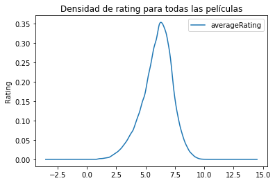

```python
pd.DataFrame(movies['averageRating']).plot(kind='density')
plt.ylabel('Rating')
plt.title(f"Densidad de rating para todas las películas")
plt.show()
```

```python
# (promedio, desviación estándar)
(movies['averageRating'].mean(), movies['averageRating'].std())
```

```
(6.001914373707608, 1.275618572859004)
```

Boxplots para “Action”

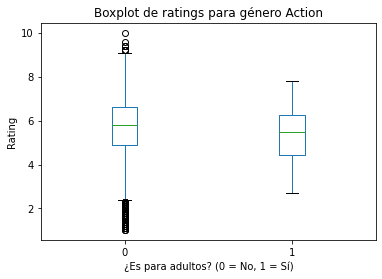

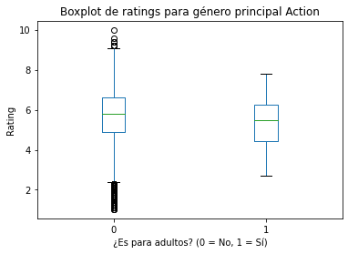

```python
boxplot_rating_por_genero("Action")
boxplot_rating_genero_principal("Action")
```

En este caso, no se ven cambios respecto a cuando “Action” es el género principal de una película o no.

Boxplots para “Drama”

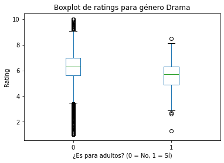

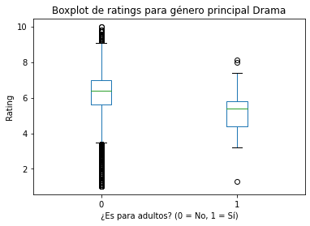

```python
boxplot_rating_por_genero("Drama")
boxplot_rating_genero_principal("Drama")
```

En este caso, si la película no es para adultos no se ven cambios, pero de serlo, la distribución cambia, ésta se traslada un poco hacia abajo, lo que significa que el primer, segundo y tercer cuartil de ratings son más bajos.

Boxplots para “Comedy”

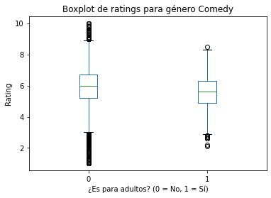

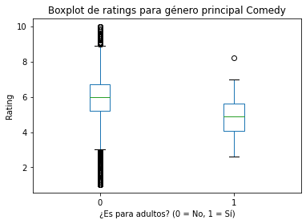

```python
boxplot_rating_por_genero("Comedy")
boxplot_rating_genero_principal("Comedy")
```

Se pueden realizar gráficos de dispersión para analizar la relación entre ciertas variables. En particular, se analizará la relación entre rating y duración, y rating y cantidad de votos para los géneros “Action”, “Drama”, “Comedy”.

Gráficos de dispersión entre rating y duración.

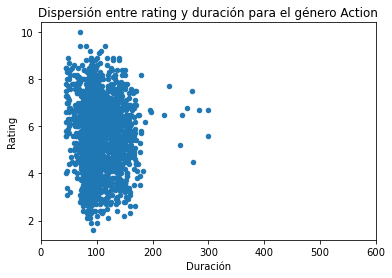

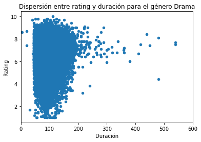

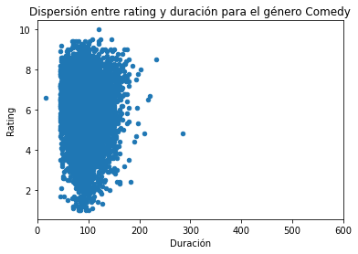

```python
dispersion_rating_duracion("Action")
dispersion_rating_duracion("Drama")
dispersion_rating_duracion("Comedy")
```

Luego de realizar el gráfico de dispersión entre rating y duración de las películas para los 3 géneros, se puede notar que los 3 son bastante similiares, aunque en el caso de "Drama" hay varios puntos con un rating relativamente alto que tienen mayor duración. Para ninguno de los 3 casos parece haber una relación clara entre las variables.

Gráficos de duración entre rating y cantidad de votos.

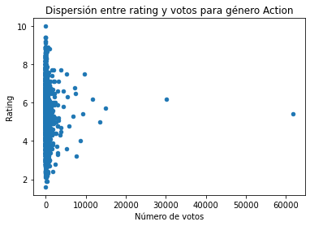

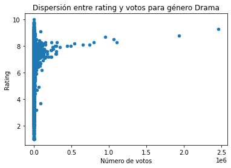

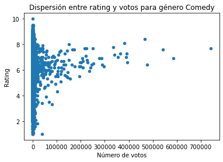

```python
dispersion_rating_votos("Action")
dispersion_rating_votos("Drama")
dispersion_rating_votos("Comedy")
```

Con los gráficos de dispersión entre rating y cantidad de votos se puede ver una clara tendencia, a partir del rating 5.0 aproximadamente comienza a haber un mayor número de votos, lo cual hace sentido, pues si una película es bien calificada más gente se verá interesada en seguir votándola.

Con los valores numéricos del dataset se puede crear una matriz de correlación. Para ver si el título de la película tiene alguna correlación con otra variable se usará el largo del título.

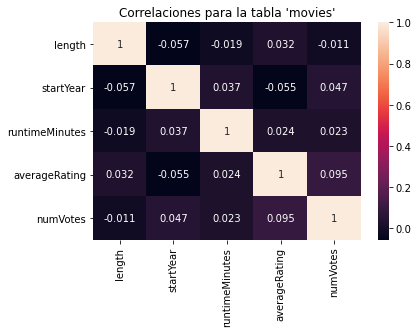

```python
df = pd.DataFrame()
df["length"] = movies["primaryTitle"].apply(len)
df["startYear"] = movies["startYear"]
df["runtimeMinutes"] = movies["runtimeMinutes"]
df["averageRating"] = movies["averageRating"]
df["numVotes"] = movies["numVotes"]
corr_df = df.corr()
plt.title("Correlaciones para la tabla 'movies'")
sns.heatmap(corr_df, annot=True)
plt.show()
```

La mayor correlación que existe es entre el rating y el número de votos, lo que es consistente con lo dicho anteriormente, pero aun así sigue siendo un valor extremadamente pequeño (ni siquiera 0.1). Entonces, se puede decir que todas las variables son prácticamente independientes entre sí.

### Reformulación de preguntas y problemas

Luego de haber agregado las columnas correspondientes a directores, escritores y actores para cada una de las películas, ahora se reformularán las preguntas y problemas. Para estas preguntas se definió éxito como la valoración y popularidad como la cantidad de votos.

- ¿Es posible predecir el éxito de una película en base a su director y su género?
- ¿Existe una relación entre el género y los clusters formados a partir de su año y duración?
- ¿Es posible predecir la popularidad de una película en base a la presencia de un actor en específico?

## Propuesta experimental

- Para responder la primera pregunta se usarán distintos métodos de clasificación. En primer lugar, se etiquetarán los datos que se necesitan para entrenar los clasificadores. Se etiquetará el éxito con 4 etiquetas, con averageRating sobre 7.5 se etiqueta con 3, entre 5 y 7.5 con 2, entre 3.5 y 5 con 1 y bajo 3.5 con 0. Luego, se debe etiquetar cada director con un id único y repetir las instancias de películas con más de un director. Esto mismo se tiene que repetir para los géneros. Con esto se entrenarán los clasificadores usando un clasificador Dummy, Árbol de Decisión, KNN, Naive-Bayes, y luego se compararan los resultados entre estos usando las métricas de precision, recall y F1-Score. Si alguna de estas métricas es mayor al 80% entonces se dirá que sí es posible la predicción.
- Para responder la pregunta 2 se usarán métodos de clasificación no supervisada como K-Means, Clustering Jerárquico Aglomerativo y DBSCAN para crear los clusters. Se probarán todos estos métodos con el año, la duración de la película, y también con cada atributo por separado para comparar cómo se generan mejor los clusters. Se evaluarán todos los clusters que se formaron usando métricas de matriz de incidencia, SSE, cohesión y separación. Finalmente se calculará la presencia relativa (i.e porcentaje de datos que pertenecen a un género) de los géneros en cada cluster y se verá si existen géneros dominantes en cada uno. Si no se evidencian géneros dominantes, significa que no existe (o no encontramos) una relación entre el género y los clusters formados a partir de su año y duración.
- Para responder la tercera pregunta nuevamente se usará clasificación supervisada. Para esto en primer lugar se deben etiquetar los datos. Para etiquetar la popularidad se seguirá un método similar al etiquetado del éxito, dividiendo la cantidad de votos en 4 intervalos y clasificando cada intervalo del 0 al 3. Luego se debe clasificar la presencia de un actor en específico con 0 si el actor no está en la película y 1 en el caso contrario. Para esto se creará una función que reciba el actor que se quiere usar para la clasificación de los datos y el año en el que empezó (y terminó si es que aplica) su carrera como actor. Esta función etiquetara con cero todos las películas que no entren en este intervalo y para el resto de los datos recorrerá los actores y etiquetara con 1 si esta presente. Esto se probara con distintos actores para hacer distintas clasificaciones. Luego, con los datos etiquetados se entrenarán los diferentes clasificadores usando un clasificador Dummy, Árbol de Decisión, KNN y Naive-Bayes para luego evaluar los resultados con precision, recall y F1-Score.

## Pre-procesamiento de los datos

Se etiqueta el rating promedio en cuatro categorías, donde 0 es "Horrible" y 3 es "Muy Bueno":

```python
def etiquetarRating(rating):
    if rating >= 7.5:
        return 3
    elif rating >= 5:
        return 2
    elif rating >= 3.5:
        return 1
    else:
        return 0

movies["etiquetaRating"] = movies["averageRating"].apply(etiquetarRating)
```

Luego, se etiquetan los directores y géneros. Para ello, se crea una tabla en donde, si una película tiene m directores y n géneros, esa fila se separará en m*n filas en la nueva tabla.

```python
from sklearn import preprocessing

etiquetas = movies[["tconst", "directors", "genres"]]

etiquetas["directors"] = etiquetas["directors"].str.split(",")
etiquetas = etiquetas.explode("directors")
etiquetaDirector = preprocessing.LabelEncoder()
etiquetaDirector.fit(etiquetas.directors)
etiquetas["etiquetaDirector"] = etiquetaDirector.transform(etiquetas.directors)

etiquetas["genres"] = etiquetas["genres"].str.split(",")
etiquetas = etiquetas.explode("genres")
etiquetaGenero = preprocessing.LabelEncoder()
etiquetaGenero.fit(etiquetas.genres)
etiquetas["etiquetaGenero"] = etiquetaGenero.transform(etiquetas.genres)
```

Finalmente, se juntan estas etiquetas con las etiquetas de rating.

```python
etiquetas = pd.merge(etiquetas, movies[['tconst', 'etiquetaRating']], on='tconst')
etiquetas
```

|  | tconst | directors | genres | etiquetaDirector | etiquetaGenero | etiquetaRating |
| --- | --- | --- | --- | --- | --- | --- |
| 0 | tt0000574 | Charles Tait | Action | 13397 | 0 | 2 |
| 1 | tt0000574 | Charles Tait | Adventure | 13397 | 2 | 2 |
| 2 | tt0000574 | Charles Tait | Biography | 13397 | 4 | 2 |
| 3 | tt0000591 | Michel Carré | Drama | 56310 | 8 | 2 |
| 4 | tt0000679 | Otis Turner | Adventure | 61748 | 2 | 2 |
| ... | ... | ... | ... | ... | ... | ... |
| 422479 | tt9916270 | Giacomo Cimini | Thriller | 27960 | 24 | 2 |
| 422480 | tt9916362 | Pablo Agüero | Adventure | 61942 | 2 | 2 |
| 422481 | tt9916362 | Pablo Agüero | Drama | 61942 | 8 | 2 |
| 422482 | tt9916362 | Pablo Agüero | History | 61942 | 12 | 2 |
| 422483 | tt9916538 | Azhar Kinoi Lubis | Drama | 7984 | 8 | 3 |

422484 rows × 6 columns

## Clasificación de datos

### Pregunta 1

Luego de haber etiquetado los datos necesarios, se clasificarán los datos utilizando varios métodos y calculando su precision, recall y F1-Score. Si alguno de estos valores entrega un valor mayor o igual a un 80% se dirá que sí se puede predecir.

La idea a seguir será realizar un cierto número de tests con distintos training set, y el valor de precision, recall y F1-Score será el promedio de todos los valores calculados.

```python
from sklearn.dummy import DummyClassifier
from sklearn.tree import DecisionTreeClassifier
from sklearn.neighbors import KNeighborsClassifier
from sklearn.naive_bayes import GaussianNB
from sklearn.metrics import f1_score, recall_score, precision_score
from sklearn.model_selection import train_test_split

def run_classifier(clf, X, y, num_tests=10, test_size=.33):
    metrics = {"precision": [], "recall": [], "f1-score": []}
    for _ in range(num_tests):
        X_train, X_test, y_train, y_test = train_test_split(X, y, test_size=test_size)
        clf.fit(X_train, y_train.values.ravel())
        predictions = clf.predict(X_test)
        metrics["y_pred"] = predictions
        metrics["precision"].append(precision_score(y_test, predictions, average='macro', zero_division=0))
        metrics["recall"].append(recall_score(y_test, predictions, average='macro'))
        metrics["f1-score"].append(f1_score(y_test, predictions, average='macro'))
    return metrics
```

```python
X = etiquetas[['etiquetaDirector', 'etiquetaGenero']]
y = etiquetas[['etiquetaRating']]

c0 = ("Base Dummy", DummyClassifier(strategy="stratified"))
c1 = ("Decision Tree", DecisionTreeClassifier(max_depth=5))
c2 = ("K-Nearest Neighbors", KNeighborsClassifier(n_neighbors=10))
c3 = ("Gaussian Naive Bayes", GaussianNB())

classifiers = [c0, c1, c2, c3]
for name, clf in classifiers:
    metrics = run_classifier(clf, X, y)
    print(f"{name}")
    print("--------------------------")
    print(f"Precision promedio: {np.array(metrics['precision']).mean()}")
    print(f"Recall promedio: {np.array(metrics['recall']).mean()}")
    print(f"F1-Score promedio: {np.array(metrics['f1-score']).mean()}")
    print("--------------------------\n\n")
```

```
Base Dummy
--------------------------
Precision promedio: 0.25024852526504854
Recall promedio: 0.2502458857456762
F1-Score promedio: 0.25024416765027924
--------------------------


Decision Tree
--------------------------
Precision promedio: 0.3688343016947086
Recall promedio: 0.25034761638808634
F1-Score promedio: 0.20811548948487385
--------------------------


K-Nearest Neighbors
--------------------------
Precision promedio: 0.43877616435734834
Recall promedio: 0.3063994560651017
F1-Score promedio: 0.3145808852193502
--------------------------


Gaussian Naive Bayes
--------------------------
Precision promedio: 0.17694860852101563
Recall promedio: 0.25
F1-Score promedio: 0.2072245083409686
--------------------------
```

Luego de probar con distintos clasificadores, es evidente que no es posible predecir el éxito de una película en base a sus directores y su género, pues el mejor resultado no pasa del 50%.

## Contribución de cada miembro

#### Alan Acevedo:

Hito 1: Obtención y limpieza de datos. Presentación.

Hito 2: Preprocesamiento de los datos. Propuestas experimentales. Corregir hito 1 según feedback.

#### Camila Labarca:

Hito 1: Gráficos de dispersión, largo de titulo para matriz de correlación, formulación de preguntas y problemas. Presentación.

Hito 2: Preprocesamiento de los datos. Propuestas experimentales. Corregir hito 1 según feedback.

#### Franco Miranda:

Hito 1: Análisis de mejores y peores películas . Funciones para gráficos. Preguntas y problemas. Presentación.

Hito 2: Preprocesamiento de los datos. Diseño de clasificadores. Propuestas experimentales. Corregir hito 1 según feedback.

#### Julia Paredes:

Hito 1: Análisis y exploración de datos, formulación de preguntas y problemas. Presentación.

Hito 2: Traducción preprocesamiento de datos hito 1 de R a python. Diapositivas. Propuestas experimentales. Corregir hito 1 según feedback.